# L5P1-Exercício 3

```r
mod1 %>%
    augment(relacao_dados_StackOverflow)
```

| country | site | gni | responderam_prop | .fitted | .resid | .hat | .sigma | .cooksd | .std.resid |
| --- | --- | --- | --- | --- | --- | --- | --- | --- | --- |
| Australia | StackOverflow | 59570 | 0.6133355 | 0.5958721 | 0.017463448 | 0.05332089 | 0.08046113 | 1.419589e-03 | 0.224516849 |
| Austria | StackOverflow | 48160 | 0.6310564 | 0.5675914 | 0.063464971 | 0.03274237 | 0.08013341 | 1.102820e-02 | 0.807204075 |
| Bangladesh | StackOverflow | 840 | 0.3928851 | 0.4503049 | -0.057419825 | 0.02543630 | 0.08020014 | 6.908248e-03 | -0.727573861 |
| Belgium | StackOverflow | 44990 | 0.6081871 | 0.5597343 | 0.048452819 | 0.02832295 | 0.08028268 | 5.509895e-03 | 0.614863077 |
| Brazil | StackOverflow | 11630 | 0.4826911 | 0.4770488 | 0.005642253 | 0.01603417 | 0.08048579 | 4.124794e-05 | 0.071151314 |
| Bulgaria | StackOverflow | 6870 | 0.5680109 | 0.4652507 | 0.102760192 | 0.01937593 | 0.07956692 | 1.664631e-02 | 1.298057623 |
| Canada | StackOverflow | 50970 | 0.6015008 | 0.5745562 | 0.026944527 | 0.03713177 | 0.08042436 | 2.274907e-03 | 0.343484765 |
| Chile | StackOverflow | 14280 | 0.4837209 | 0.4836170 | 0.000103888 | 0.01472513 | 0.08048855 | 1.280814e-08 | 0.001309204 |
| China | StackOverflow | 5680 | 0.3557197 | 0.4623012 | -0.106581509 | 0.02041019 | 0.07949562 | 1.890310e-02 | -1.347038709 |
| Colombia | StackOverflow | 6990 | 0.4779412 | 0.4655482 | 0.012393002 | 0.01927605 | 0.08047522 | 2.408176e-04 | 0.156539328 |

[output cut: 66 more lines]

GRÁFICO COM O Y real e y ESTIMADO

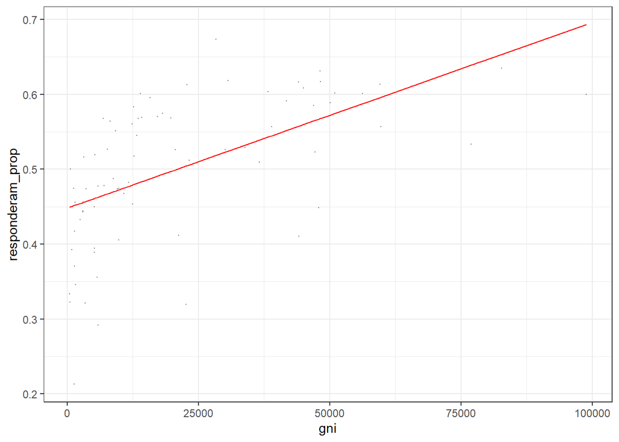

```r
mod1 %>%
    augment(relacao_dados_StackOverflow) %>%
    ggplot(mapping =  aes(x = gni)) +
    geom_point(aes(y = responderam_prop), alpha = 0.4, size = .1) +
    geom_line(aes(y = .fitted), colour = "red")
```

```r
    NULL
```

Inferência

```r
mod1 %>%
    tidy(conf.int = T, conf.level = 0.95) %>%
    select(-p.value)
```

| term | estimate | std.error | statistic | conf.low | conf.high |
| --- | --- | --- | --- | --- | --- |
| (Intercept) | 4.482229e-01 | 1.299965e-02 | 34.479619 | 4.223205e-01 | 4.741252e-01 |
| gni | 2.478583e-06 | 4.236237e-07 | 5.850906 | 1.634494e-06 | 3.322671e-06 |

O gráfico de dispersão mostra comportamentos das variáveis respoderam_prop e GNI . Considera-se respoderam_prop como variável dependente e GNI como variáveil independente. O gráfico de dispersão mostra uma possível relação positiva entre essas variáveis por visualizar que seus pontos amostrais indicam uma reta positivamente inclinada. Também, é possível que a melhor função matemática que descreva a relação entre essas duas variáveis possa não ser um modelo linear. Inicialmente, estima-se um modelo linear com as variáveis em nível, ou seja, com seus valores originais. Em seguida, estima-se um modelo transformando as variáveis (dependente e independete) em logarítimo para linearizar essa relação.

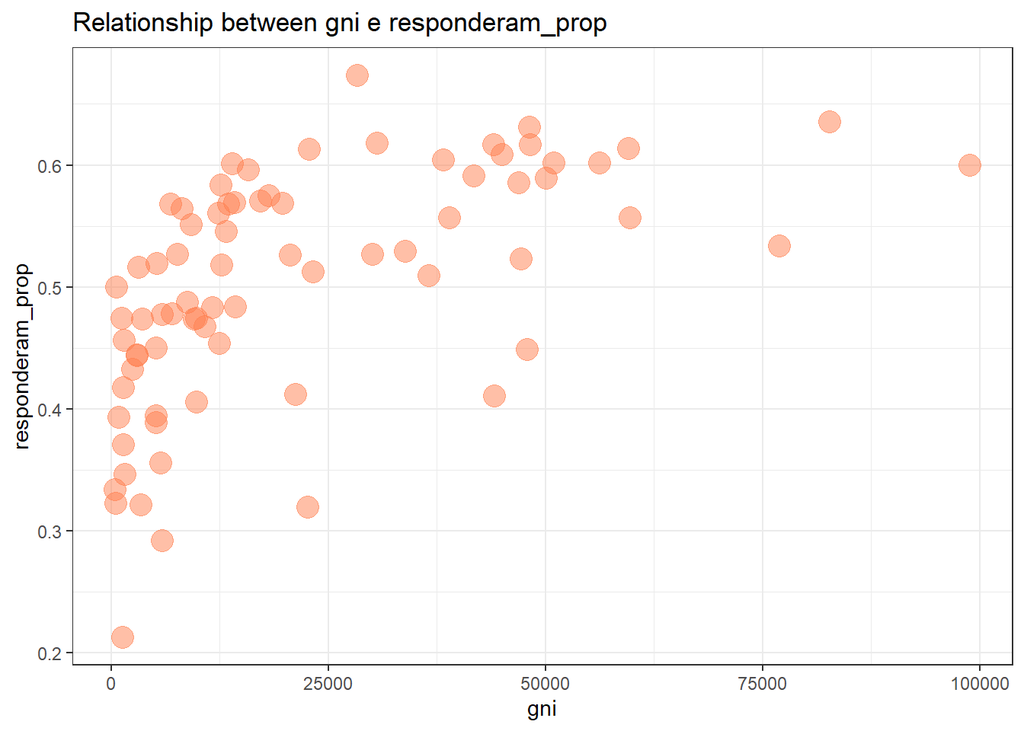

```r
relacao_dados_StackOverflow %>%
ggplot(aes(x = gni, y = responderam_prop)) +
  geom_point(size = 5, alpha = .5, color = "coral") +

  labs(x = "gni", y = "responderam_prop",
       title = "Relationship between gni e responderam_prop")
```